# Reproducible Research: Peer Assessment 1

## Loading and preprocessing the data

**1. Load the data and the required packages:**

```r
data <- read.csv("activity.csv")
library(tidyverse)
```

**2. Prepocess the data: calculate total number of steps per day**

```r
day_total1 <- data %>%
    group_by(date) %>%
    summarise(total = sum(steps, na.rm = TRUE)) %>%
    mutate(NA_status = "NA_present")
```

## What is mean total number of steps taken per day?

**1. Total number of steps taken each day:**

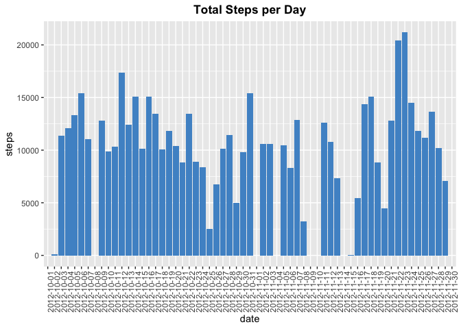

```r
ggplot(day_total1, aes(date, total)) +
    geom_bar(stat = "identity", fill = "steelblue3") +
    labs(y = "steps", title = "Total Steps per Day") +
    theme(axis.text.x = element_text(angle = 90), plot.title = element_text(hjust = 0.5, face = "bold"))
```

**2. Mean and median total number of steps taken per day**

```r
mean_steps1 <- mean(day_total1$total, na.rm = TRUE)
median_steps1 <- median(day_total1$total, na.rm = TRUE)
```

Mean number of steps taken per day is **9354** and median is **10395**

## What is the average daily activity pattern?

**1. Average number of steps taken per interval**

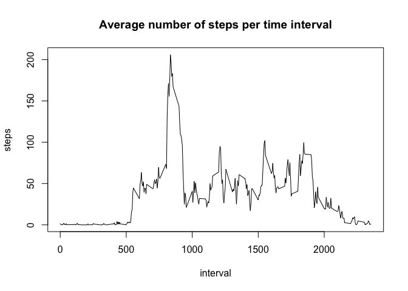

```r
interval_av <- data %>%
    group_by(interval) %>%
    summarise(interval_steps = mean(steps, na.rm = TRUE))

with(interval_av, plot(interval, interval_steps, type = "l", ylab = "steps", main = "Average number of steps per time interval"))
```

```r
max_interval <- unlist(interval_av[interval_av$interval_steps == max(interval_av$interval_steps), "interval"])
```

The interval with maximum average number of steps is **835**

## Imputing missing values

**1. Calculate total number of missing values in the dataset**

```r
nas <- colSums(is.na(data))
nas <- t(as.data.frame(nas))
rownames(nas) <- NULL

knitr::kable(nas, format = "html", table.attr = "style='width:30%;'")
```

| steps | date | interval |
| --- | --- | --- |
| 2304 | 0 | 0 |

**2. Fill in the missing values in the dataset**

NAs in the data set were replaced with the mean value of the correspoding interval

```r
data_na_rm <- data
for(i in 1:nrow(data_na_rm)) {
    if (is.na(data_na_rm[i, "steps"])) {
        data_na_rm[i, "steps"] <- interval_av[interval_av$interval == data_na_rm[i, "interval"], "interval_steps"]
    }
}
```

**3. Compare total number of steps taken each day in data with NAs present and NAs imputed**

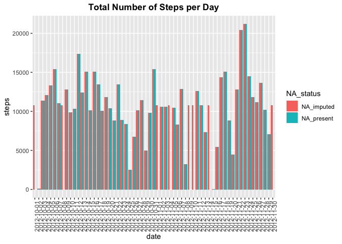

```r
day_total2 <- data_na_rm %>%
    group_by(date) %>%
    summarise(total = sum(steps, na.rm = TRUE)) %>%
    mutate(NA_status = "NA_imputed")

mean_steps2 <- round(mean(day_total2$total), 0)
median_steps2 <- round(median(day_total2$total), 0)

day_total <- rbind(day_total1, day_total2)
ggplot(day_total, aes(date, total)) +
    geom_bar(aes(fill = NA_status), stat = "identity", position = "dodge") +
    theme(axis.text.x = element_text(angle = 90), plot.title = element_text(hjust = 0.5, face = "bold")) +
    labs(y = "steps", title = "Total Number of Steps per Day")
```

Mean number of steps taken per day is **10766** and median is **10766**. These numbers are higher than the mean and median calculated without imputing missing values.

## Are there differences in activity patterns between weekdays and weekends?

**1. Create a new factor variable in the dataset with two levels – “weekday” and “weekend” indicating whether a given date is a weekday or weekend day**

```r
data_na_rm$date <- as.Date(data_na_rm$date, "%Y-%m-%d")
data_na_rm$weekdays <- weekdays(data_na_rm$date)
data_na_rm$days <- ifelse(data_na_rm$weekdays %in% c("Saturday", "Sunday"), "weekend", "weekday")
data_na_rm_week <- data_na_rm %>%
    group_by(days, interval) %>%
    summarise(total = mean(steps))

data_na_rm_week$days <- as.factor(data_na_rm_week$days)
```

**2. Make a panel plot containing a time series plot of the 5-minute interval (x-axis) and the average number of steps taken, averaged across all weekday days or weekend days (y-axis)**

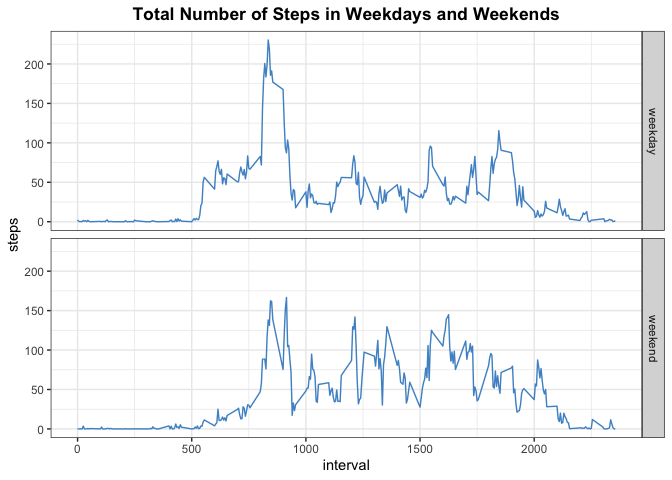

```r
ggplot(data_na_rm_week, aes(interval, total)) +
    geom_line(color = "steelblue3") +
    facet_grid(days~.) +
    labs(y = "steps", title = "Total Number of Steps in Weekdays and Weekends") +
    theme_bw() +
    theme(plot.title = element_text(hjust = 0.5, face = "bold"))
```